# Red Wines Quality Exploration

*by NK Zhehua Zou*

### 1.Citation

This dataset is public available for research. The details are described in [Cortez et al., 2009].  
P. Cortez, A. Cerdeira, F. Almeida, T. Matos and J. Reis.  
Modeling wine preferences by data mining from physicochemical properties.  
In Decision Support Systems, Elsevier, 47(4):547-553. ISSN: 0167-9236.

### 2.About dataset

This tidy data set contains 1,599 red wines with 11 variables on the chemical properties of the wine. At least 3 wine experts rated the quality of each wine, providing a rating between 0 (very bad) and 10 (very excellent).

### 3.Attribute information

Input variables (based on physicochemical tests):  
1 - fixed acidity (tartaric acid - g / dm^3)  
2 - volatile acidity (acetic acid - g / dm^3)  
3 - citric acid (g / dm^3)  
4 - residual sugar (g / dm^3)  
5 - chlorides (sodium chloride - g / dm^3  
6 - free sulfur dioxide (mg / dm^3)  
7 - total sulfur dioxide (mg / dm^3)  
8 - density (g / cm^3)  
9 - pH  
10 - sulphates (potassium sulphate - g / dm3)  
11 - alcohol (% by volume)  
Output variable (based on sensory data):  
12 - quality (score between 0 and 10)

### 4.Description of attributes:

1 - fixed acidity: most acids involved with wine or fixed or nonvolatile (do not evaporate readily)  
2 - volatile acidity: the amount of acetic acid in wine, which at too high of levels can lead to an unpleasant, vinegar taste  
3 - citric acid: found in small quantities, citric acid can add ‘freshness’ and flavor to wines  
4 - residual sugar: the amount of sugar remaining after fermentation stops, it’s rare to find wines with less than 1 gram/liter and wines with greater than 45 grams/liter are considered sweet  
5 - chlorides: the amount of salt in the wine  
6 - free sulfur dioxide: the free form of SO2 exists in equilibrium between molecular SO2 (as a dissolved gas) and bisulfite ion; it prevents microbial growth and the oxidation of wine  
7 - total sulfur dioxide: amount of free and bound forms of S02; in low concentrations, SO2 is mostly undetectable in wine, but at free SO2 concentrations over 50 ppm, SO2 becomes evident in the nose and taste of wine  
8 - density: the density of water is close to that of water depending on the percent alcohol and sugar content  
9 - pH: describes how acidic or basic a wine is on a scale from 0 (very acidic) to 14 (very basic); most wines are between 3-4 on the pH scale  
10 - sulphates: a wine additive which can contribute to sulfur dioxide gas (S02) levels, wich acts as an antimicrobial and antioxidant  
11 - alcohol: the percent alcohol content of the wine  
12 - quality (score between 0 and 10)

# Analysis Section

This analysis will focus on the following key parameters:  
1) pH: pH value is considered to be a key parameter for the determination of quality of wine and hence the analysis focussed on determining the impact of these pH values on final quality determination.  
2) SO2: SO2 has been always a debatable topic due to the allergic reactions associated with SO2.The current analysis tries to determine the impact of SO2 on pH values and the final quality values for the wine samples.  
3) Alcohol: Alcohol content is an important parameter considered when a buyer purchases any alcoholic product and this analysis tries to unravel relationship of Alcohol content with parmaters like pH values and SO2 contents and the impact to quality.

*First of all, variable “X” is an index variable. We’ll drop it from the analysis.*

### Summary of the Data Set

1. Head of dataset

```
##   fixed.acidity volatile.acidity citric.acid residual.sugar chlorides
## 1           7.4             0.70        0.00            1.9     0.076
## 2           7.8             0.88        0.00            2.6     0.098
## 3           7.8             0.76        0.04            2.3     0.092
## 4          11.2             0.28        0.56            1.9     0.075
## 5           7.4             0.70        0.00            1.9     0.076
## 6           7.4             0.66        0.00            1.8     0.075
##   free.sulfur.dioxide total.sulfur.dioxide density   pH sulphates alcohol
## 1                  11                   34  0.9978 3.51      0.56     9.4
## 2                  25                   67  0.9968 3.20      0.68     9.8
## 3                  15                   54  0.9970 3.26      0.65     9.8
## 4                  17                   60  0.9980 3.16      0.58     9.8
## 5                  11                   34  0.9978 3.51      0.56     9.4
## 6                  13                   40  0.9978 3.51      0.56     9.4
##   quality
## 1       5
## 2       5
## 3       5
## 4       6
## 5       5
## 6       5
```

2. Names of variables in dataset

```
##  [1] "fixed.acidity"        "volatile.acidity"     "citric.acid"
##  [4] "residual.sugar"       "chlorides"            "free.sulfur.dioxide"
##  [7] "total.sulfur.dioxide" "density"              "pH"
## [10] "sulphates"            "alcohol"              "quality"
```

3. Str of dataset

```
## 'data.frame':    1599 obs. of  12 variables:
##  $ fixed.acidity       : num  7.4 7.8 7.8 11.2 7.4 7.4 7.9 7.3 7.8 7.5 ...
##  $ volatile.acidity    : num  0.7 0.88 0.76 0.28 0.7 0.66 0.6 0.65 0.58 0.5 ...
##  $ citric.acid         : num  0 0 0.04 0.56 0 0 0.06 0 0.02 0.36 ...
##  $ residual.sugar      : num  1.9 2.6 2.3 1.9 1.9 1.8 1.6 1.2 2 6.1 ...
##  $ chlorides           : num  0.076 0.098 0.092 0.075 0.076 0.075 0.069 0.065 0.073 0.071 ...
##  $ free.sulfur.dioxide : num  11 25 15 17 11 13 15 15 9 17 ...
##  $ total.sulfur.dioxide: num  34 67 54 60 34 40 59 21 18 102 ...
##  $ density             : num  0.998 0.997 0.997 0.998 0.998 ...
##  $ pH                  : num  3.51 3.2 3.26 3.16 3.51 3.51 3.3 3.39 3.36 3.35 ...
##  $ sulphates           : num  0.56 0.68 0.65 0.58 0.56 0.56 0.46 0.47 0.57 0.8 ...
##  $ alcohol             : num  9.4 9.8 9.8 9.8 9.4 9.4 9.4 10 9.5 10.5 ...
##  $ quality             : int  5 5 5 6 5 5 5 7 7 5 ...
```

4. Summary of red wines

```
##  fixed.acidity   volatile.acidity  citric.acid    residual.sugar
##  Min.   : 4.60   Min.   :0.1200   Min.   :0.000   Min.   : 0.900
##  1st Qu.: 7.10   1st Qu.:0.3900   1st Qu.:0.090   1st Qu.: 1.900
##  Median : 7.90   Median :0.5200   Median :0.260   Median : 2.200
##  Mean   : 8.32   Mean   :0.5278   Mean   :0.271   Mean   : 2.539
##  3rd Qu.: 9.20   3rd Qu.:0.6400   3rd Qu.:0.420   3rd Qu.: 2.600
##  Max.   :15.90   Max.   :1.5800   Max.   :1.000   Max.   :15.500
##    chlorides       free.sulfur.dioxide total.sulfur.dioxide
##  Min.   :0.01200   Min.   : 1.00       Min.   :  6.00
##  1st Qu.:0.07000   1st Qu.: 7.00       1st Qu.: 22.00
##  Median :0.07900   Median :14.00       Median : 38.00
##  Mean   :0.08747   Mean   :15.87       Mean   : 46.47
##  3rd Qu.:0.09000   3rd Qu.:21.00       3rd Qu.: 62.00
##  Max.   :0.61100   Max.   :72.00       Max.   :289.00
##     density             pH          sulphates         alcohol
##  Min.   :0.9901   Min.   :2.740   Min.   :0.3300   Min.   : 8.40
##  1st Qu.:0.9956   1st Qu.:3.210   1st Qu.:0.5500   1st Qu.: 9.50
##  Median :0.9968   Median :3.310   Median :0.6200   Median :10.20
##  Mean   :0.9967   Mean   :3.311   Mean   :0.6581   Mean   :10.42
##  3rd Qu.:0.9978   3rd Qu.:3.400   3rd Qu.:0.7300   3rd Qu.:11.10
##  Max.   :1.0037   Max.   :4.010   Max.   :2.0000   Max.   :14.90
##     quality
##  Min.   :3.000
##  1st Qu.:5.000
##  Median :6.000
##  Mean   :5.636
##  3rd Qu.:6.000
##  Max.   :8.000
```

# Univariate Plots and Analysis

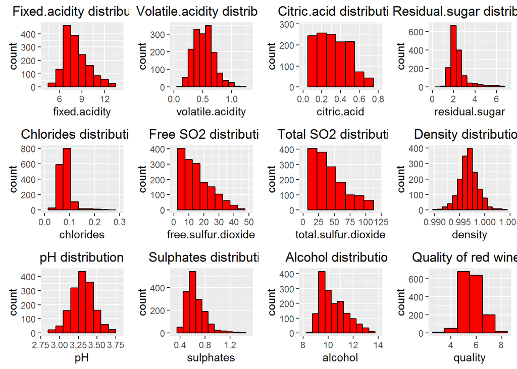

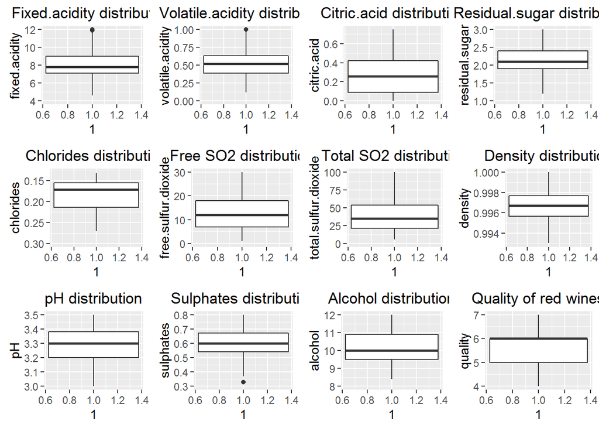

# Bivariate and Multivariate Plots and Analysis

### 1. Investigate what are the features influencing quality

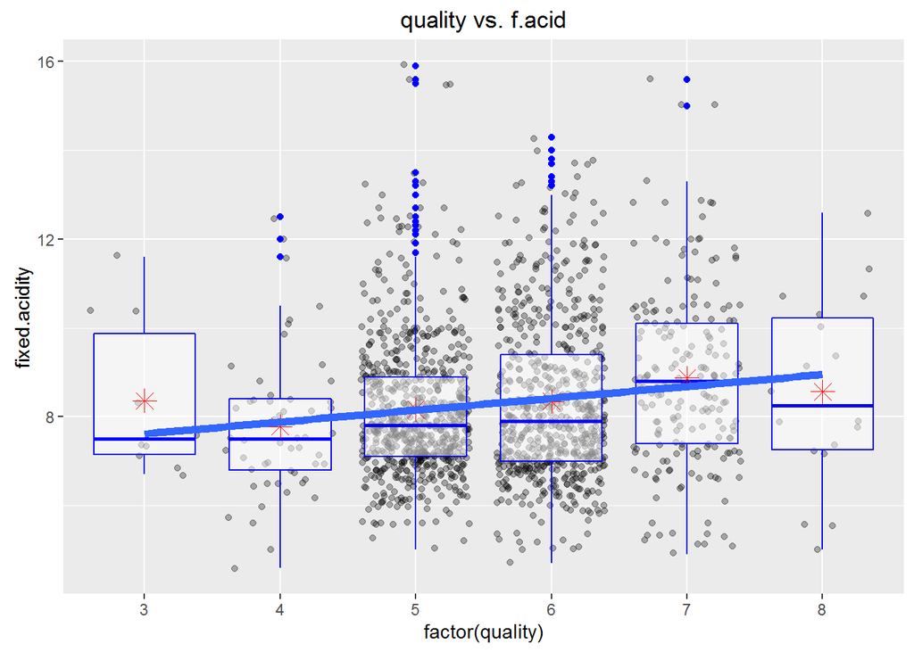

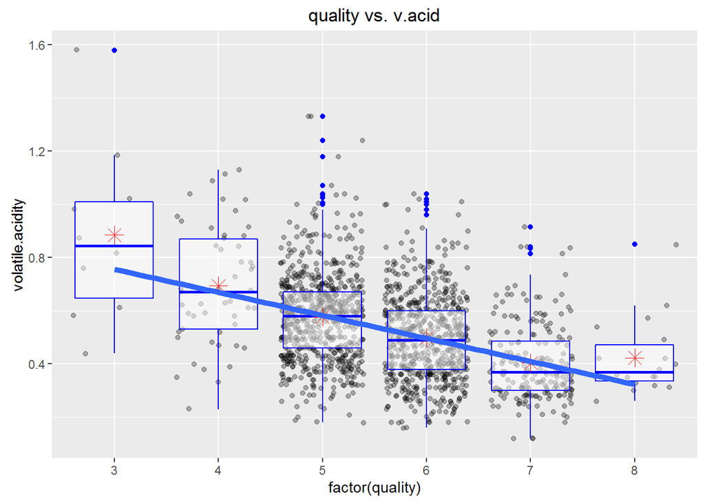

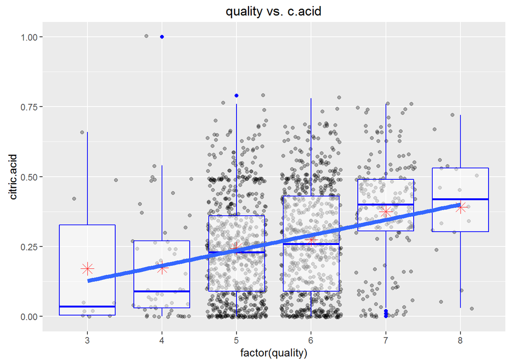

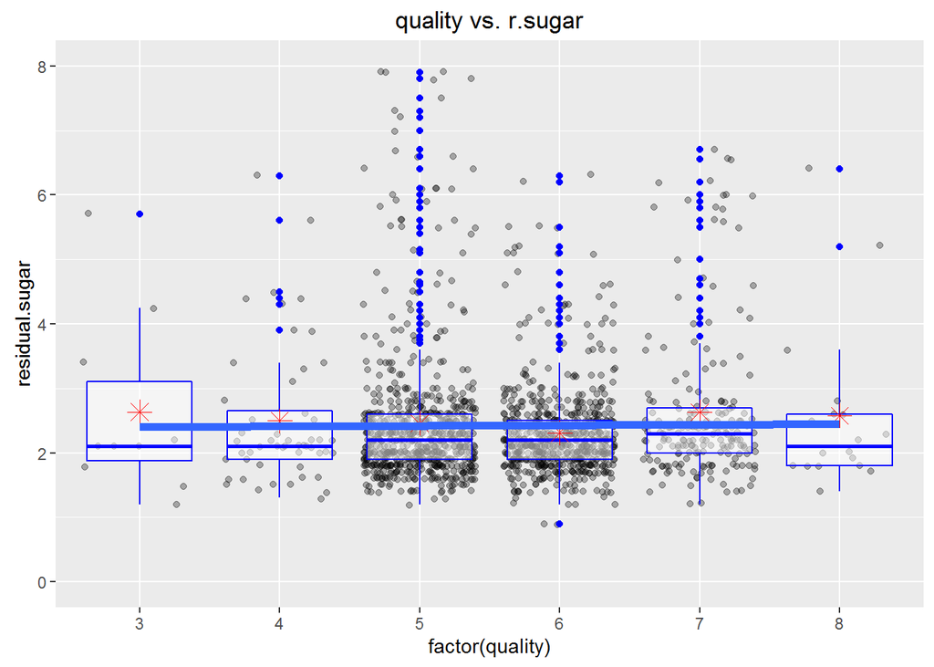

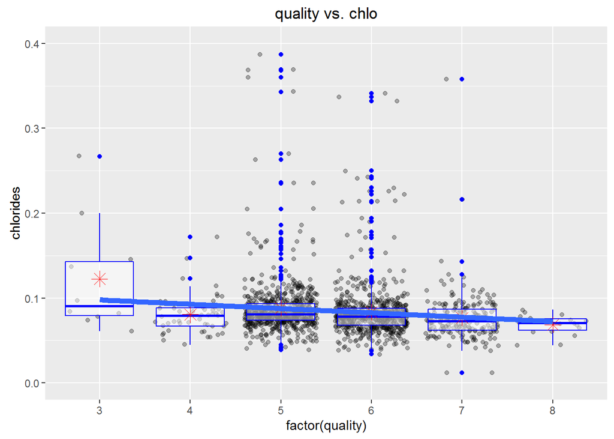

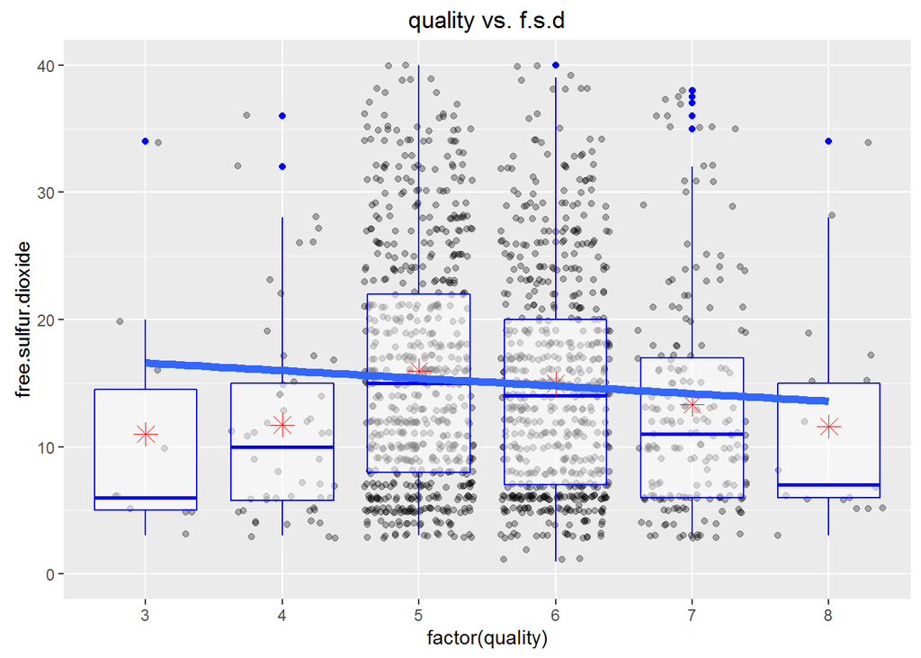

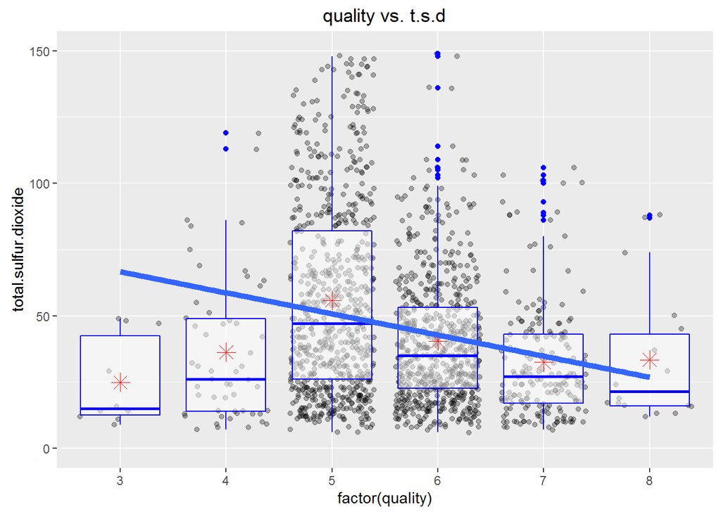

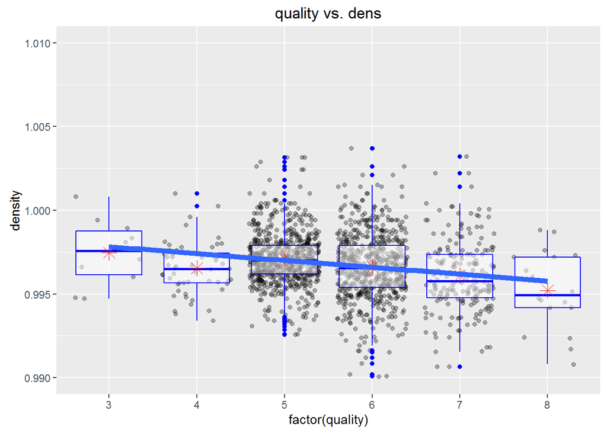

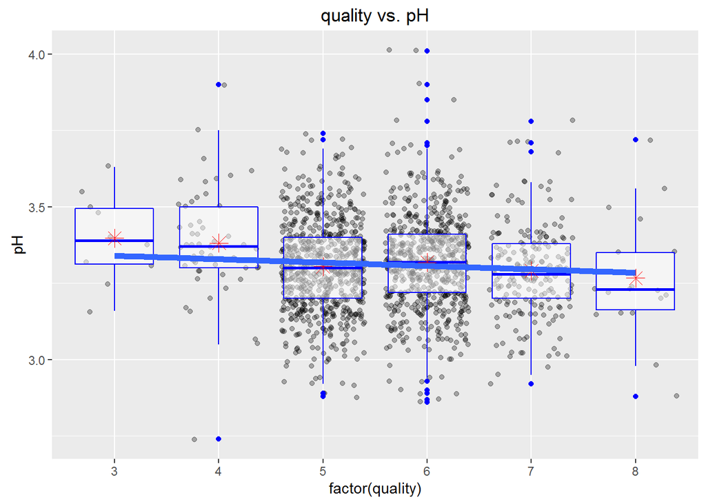

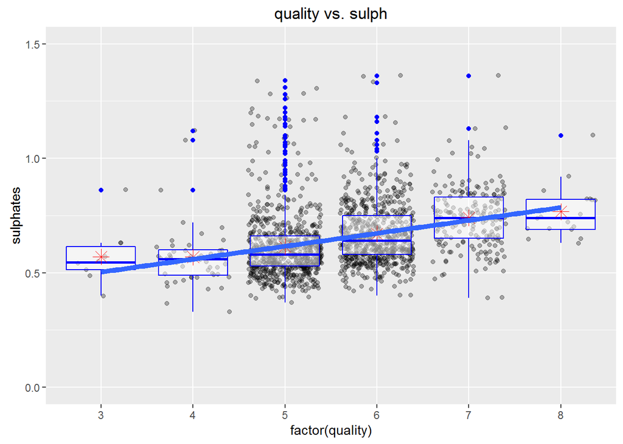

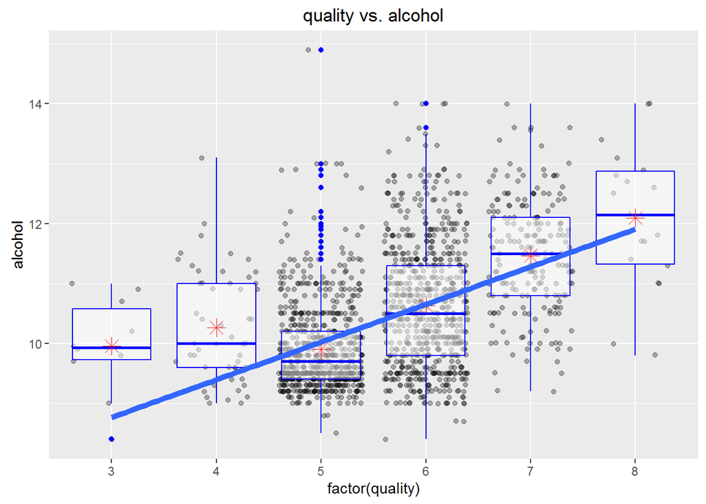

1. The scatter plot of quality vs volatile acidity not only shows all the volatible acidity of each quality, but also shows the mean volatile acidity. High quality red wines appears to have smaller volatile acidity, except the red wines with highest quality 8. However, the relationship between quality and fixed.acidity is more complex.
2. The plot shows that high-quality red wine tends to have high citric acid. But citric acid is not a detrminant factor. There is one point with citric acid 1 but with quality only 4.
3. The scatter plot of quality against sulphates show that high- quality red wine has higher mean sulphates.
4. High alcohol red wine has higher quality score. Red wine below the mean quality has alcohol around 10.42, while red wine above mean quality has obvious higher alcohol.
4. High quality wine tends to have lower volatile acidity, higher citric acid, higher sulphates, and higher alcohol. No obvious relationship is observed between quality and other features.

### 2. We can see some strong correlation in pairs below:

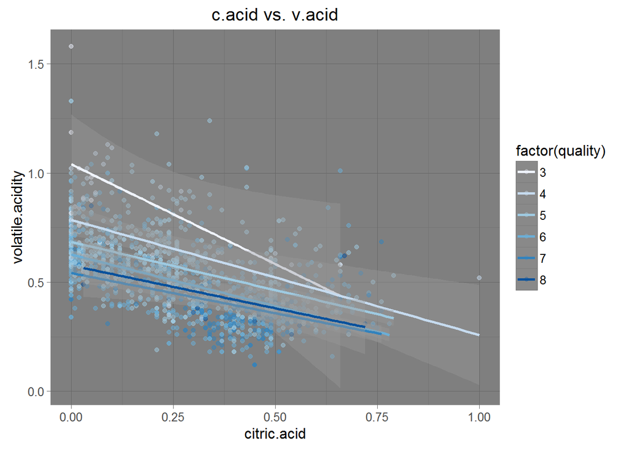

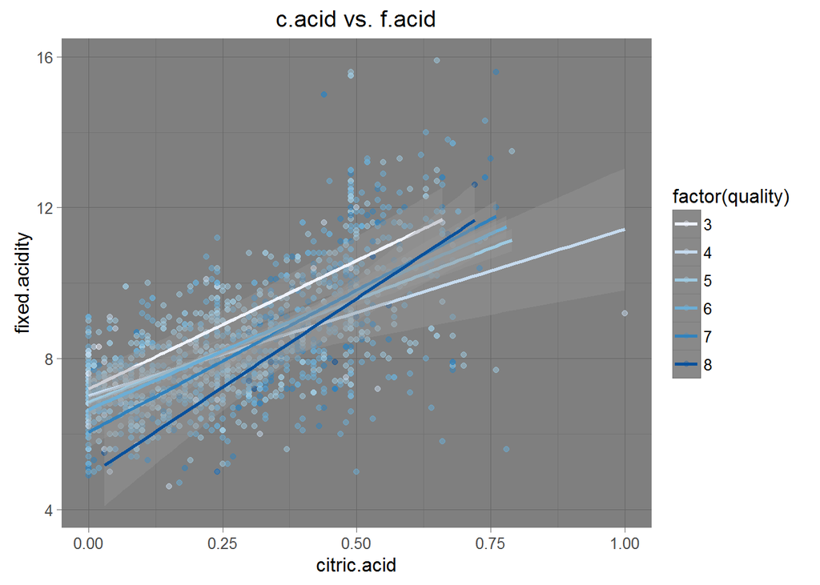

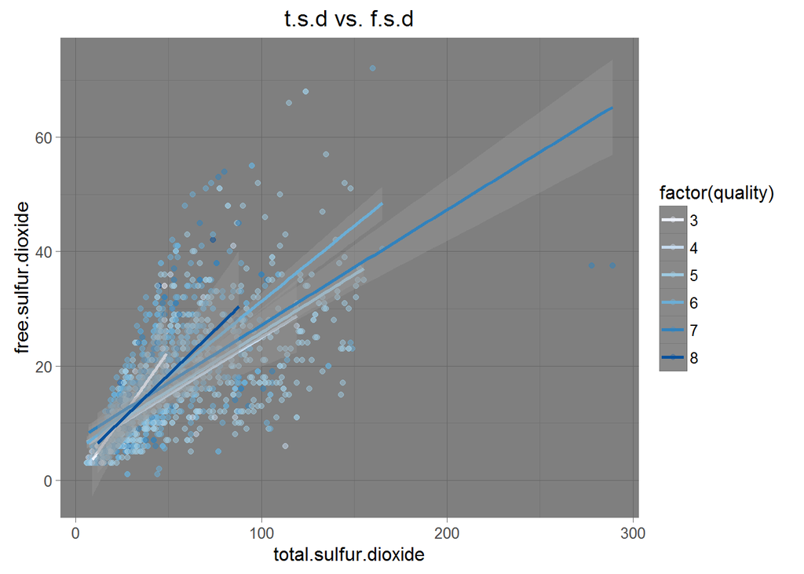

[figure not shown]

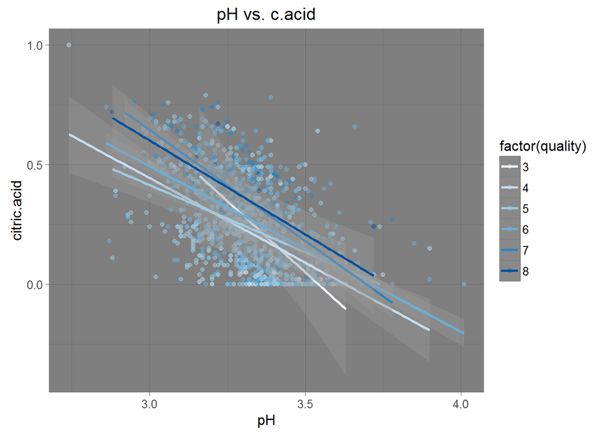

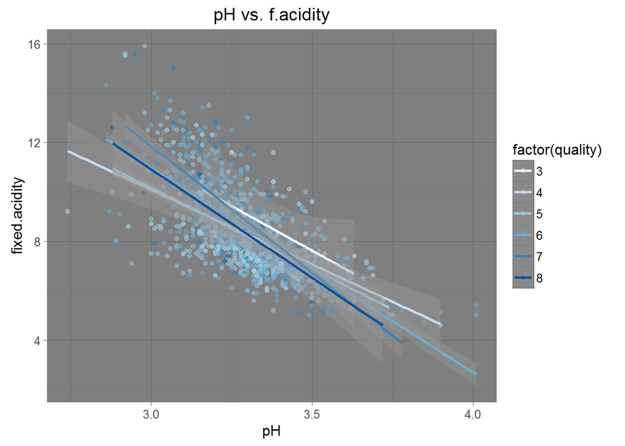

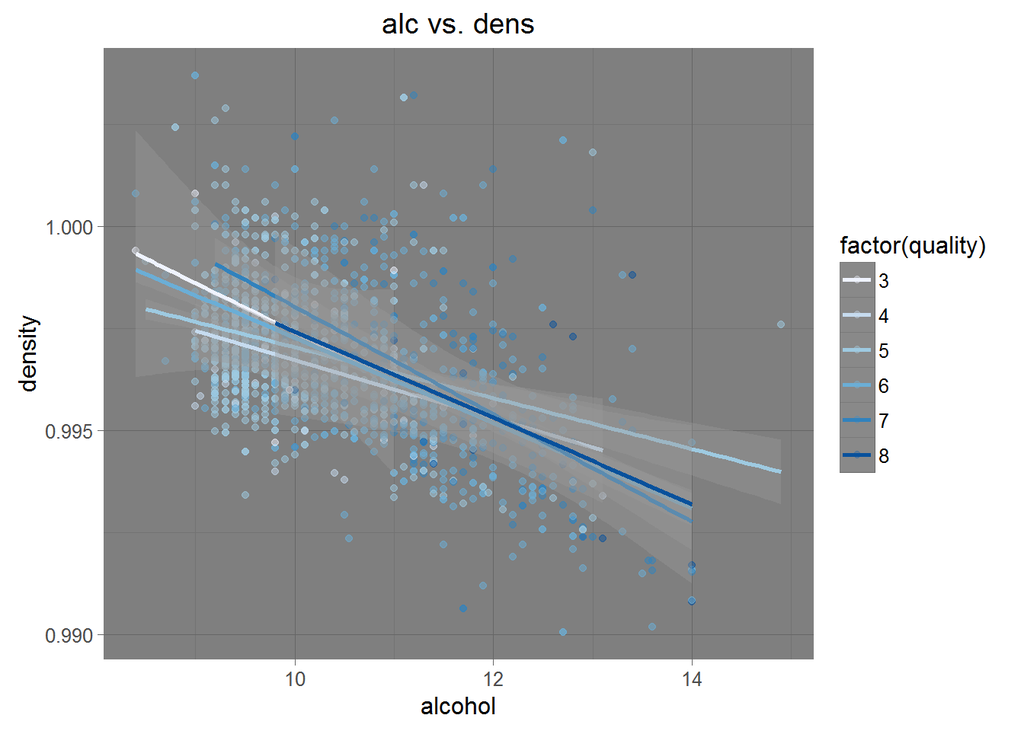

1. High citric.acid has low volatile.acidity and high quality.
2. High citric.acid has high fixed.acidity and high quality.
3. High free.sulfur.dioxide has high total.sulfur.dioxide.
4. High density has high fixed.acidity.
5. High pH has low citric.acid.
6. High pH has low fixed.acidity.
7. High alcohol has low density and high quality.

### 3. Correlation between all the variables in dataset

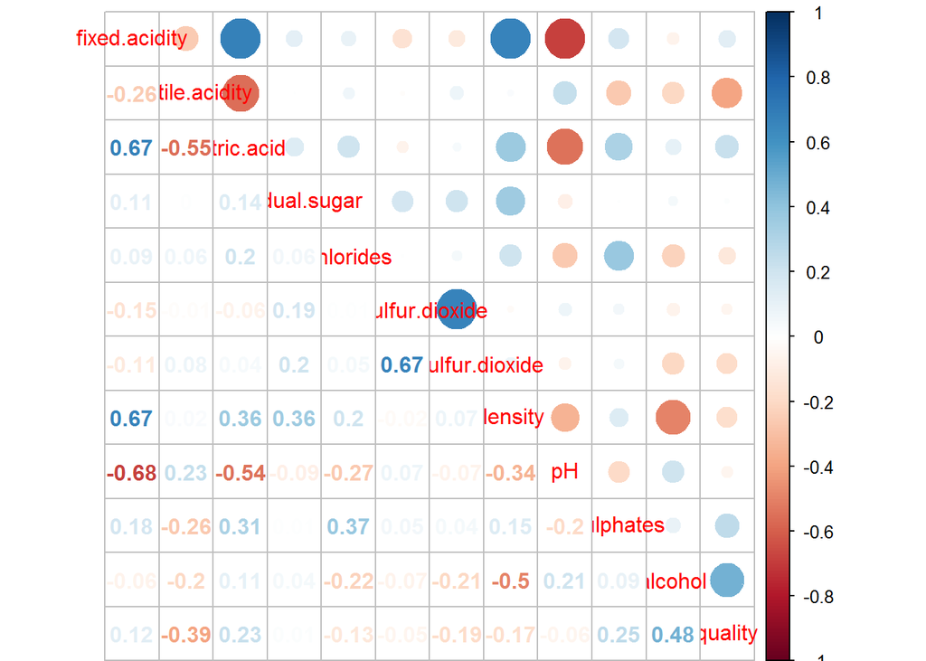

# Final Plots and Summary

### Plot One - Alcohol vs. Quality

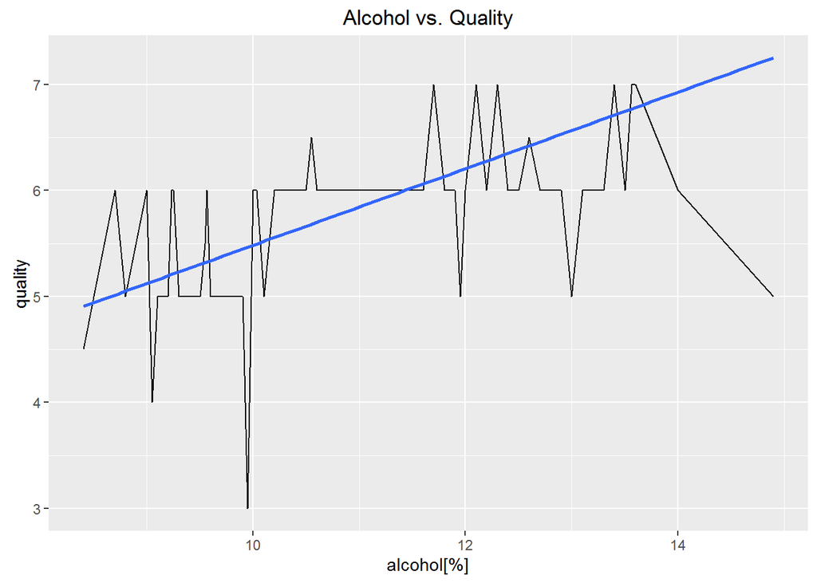

1. We found alcohol and quality have strongest correlation accoding to corrplot.
2. Because we have used boxplot to present the correlation between alcohol and quality and we will use point plot as last plot, so we have to use lineplot and linear regression model to predict and verify this correlation if strong enough.
3. In this plotting, we can see has strong correlation between Alcohol and Quality. Higher alcohol has higher quality.
4. But I found an interesting thing from this plot, higher alcohol has lower quality if alcohol greater than 13.5%? I think there has other factors to affect the quality.

### Plot Two - Density vs. Alcohol

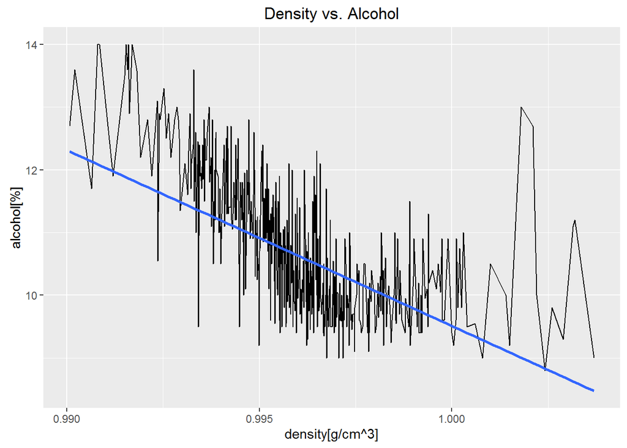

### Plot Three - Alcohol vs. Density vs. Quality

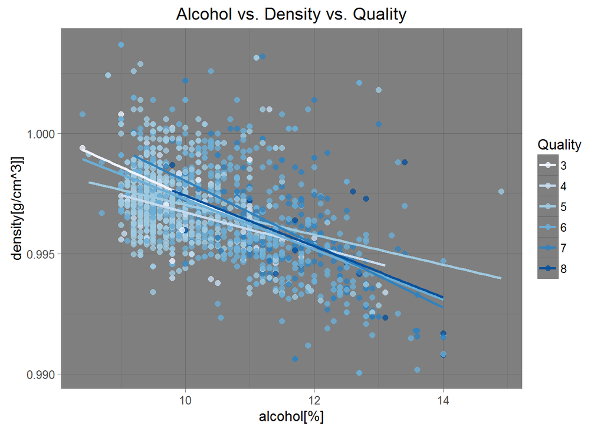

1. I belive the scatter plot with linear regression is a best way to present correlation of multive vectors.
2. In this plotting, we can see higher alcohol and lower dentisy have higher quality.

### Reflection

This data set contains 1599 red wines. Each wine has 12 functions. First, I use histograms and boxplots to investigate each individual feature. I found the quality of red wine from expert grading 0 to 10 points. In the data set, about 80% of the red wines score 5 and 6, very low scores and higher scores. Quality is too clustered. When I do corrplot, I observe the relevance of each function. After that, I explored the quality of red wine in other functions, and studied which properties determine the quality of red wine. Found that the quality and alcohol, volatile acidity, citric acid, sulfate is closely related.

According to my survey, I can conclude that the experts’ decision on the quality level of the wine is based on their personal test or can depend on other variables such as the year of production, the grape variety, the wine brand and so on. Because there is only one variable (alcohol level) and related wines.  
For future work, I would like to obtain more data sets in the winemaking area to eliminate regional bias because the current data only include samples collected from specific Portuguese regions.

### References

1. P. Cortez, A. Cerdeira, F. Almeida, T. Matos and J. Reis. Modeling wine preferences by data mining from physicochemical properties.In Decision Support Systems, Elsevier, 47(4):547-553. ISSN: 0167-9236.
2. Red and White Wine Quality by Daria Alekseeva, https://rpubs.com/Daria/57835
3. Wine Quality Analysis, http://rstudio-pubs-static.s3.amazonaws.com/24803_abbae17a5e154b259f6f9225da6dade0.html
4. Red wine quiality exploration by Martin Pons, https://rstudio-pubs-static.s3.amazonaws.com/109021_0011c9e396e949ea9fa60ae3c64f07dd.html
5. Red Wine Exploration by Zhang Guanghui, http://www.guanghuiz.com/en/data-science/data-exploration-project-1.html